# HuggingFace Transformer Pipeline : Sentiment Analysis

In this notebook, we will use the pre-trained [HuggingFace's Transformer Pipeline : Sentiment Analysis](https://huggingface.co/docs/transformers/task_summary#sequence-classification) to predict the sentiment of the tweets.

We will compare this pre-trained local model to the baseline model from 1_baseline.ipynb.

## Load project modules and data

We will use basic python packages, and the [HuggingFace](https://huggingface.co/docs/transformers/quicktour) package to predict text sentiment.

```python
# Import custom helper libraries
import os
import sys

# Maths modules
import pandas as pd


src_path = os.path.abspath(os.path.join("../src"))
if src_path not in sys.path:
    sys.path.append(src_path)

import data.helpers as data_helpers
import visualization.helpers as viz_helpers


# Sample data for development
TEXT_SAMPLE_SIZE = 2000  # <= 0 for all
```

```python
# Download and unzip CSV files
!cd .. && make dataset && cd notebooks
```

```
>>> Downloading and extracting data files...
Data files already downloaded.
>>> OK.
```

```python
# Load data from CSV
df = pd.read_csv(
    os.path.join("..", "data", "raw", "training.1600000.processed.noemoticon.csv"),
    names=["target", "id", "date", "flag", "user", "text"],
)

# Reduce memory usage
df = data_helpers.reduce_dataframe_memory_usage(df)

# Drop useless columns
df.drop(columns=["id", "date", "flag", "user"], inplace=True)

# Replace target values with labels
df.target = df.target.map(
    {
        0: "NEGATIVE",
        2: "NEUTRAL",
        4: "POSITIVE",
    }
)

# Sample data
if TEXT_SAMPLE_SIZE > 0:
    df = data_helpers.balance_sample(df, "target", TEXT_SAMPLE_SIZE)

df.describe()
```

|  | target | text |
| --- | --- | --- |
| count | 2000 | 2000 |
| unique | 2 | 2000 |
| top | NEGATIVE | @xnausikaax oh no! where did u order from? tha... |
| freq | 1000 | 1 |

## Classification Model

Now we can measure the performance of our model defined in custom_huggingface_sentiment_analysis_classifier.py. We are going to use the same metrics as our baseline model defined in 1_baseline.ipynb.

### HuggingFace's Transformer Pipeline : Sentiment Analysis model

In this model, we will use the pre-trained HuggingFace's Transformer Pipeline Sentiment Analysis to predict the sentiment of the tweets.

[output not shown]

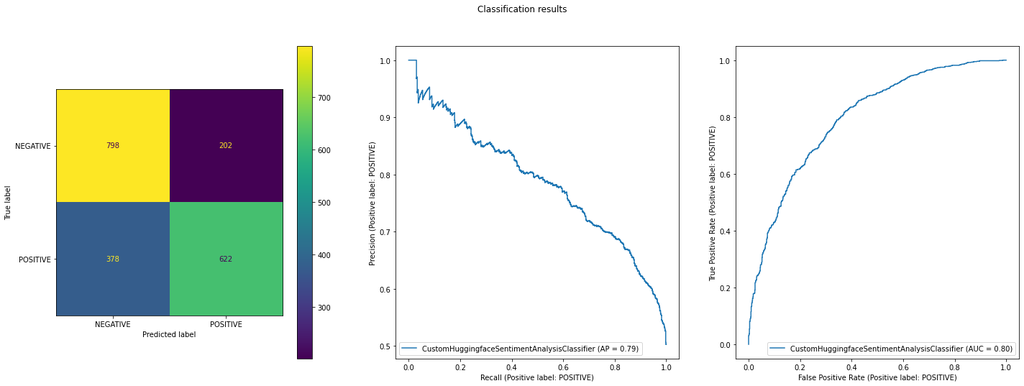

```python
from models.custom_huggingface_sentiment_analysis_classifier import (
    CustomHuggingfaceSentimentAnalysisClassifier,
)


# Initialize Azure Text Analytics classifier
cls = CustomHuggingfaceSentimentAnalysisClassifier()

cache_json_path = os.path.join("..", "results", "huggingface_cache.json")
if os.path.exists(cache_json_path):
    # Load cached results
    cls.load_cache_json(filename=cache_json_path)
else:
    # Compute sentiment scores
    cls.fit(X=df.text.values, y=df.target.values)
    # Save results to cache
    cls.save_cache_json(filename=cache_json_path)

# Plot classification performances
viz_helpers.plot_classifier_results(
    cls,
    df.text.values,
    df.target.values,
    title="Classification results",
)
```

The performances on the dataset are quite better than our baseline model :

- Average Precision = 0.79 (baseline = 0.73 , +8.2%)
- ROC AUC = 0.80 (baseline = 0.74 , +8.1%)

Let's observe some classification errors.

```python
# Compute predictions
y_pred = cls.predict(df.text.values)
df["prediction"] = y_pred
```

```python
import shap

shap.initjs()

explainer = shap.Explainer(cls.classifier)
```

```python
# False positive example
fp_index = df[(df.target == "NEGATIVE") & (df.prediction == "POSITIVE")].index[0]
fp_text = df.text.values[fp_index]

shap_values = explainer([fp_text])

shap.plots.text(shap_values[0, :, "POSITIVE"])
```

```
Partition explainer: 2it [00:34, 34.54s/it]
```

[figure not shown]

On this false-positive example, we can see that the model is not able to predict the *NEGATIVE* sentiment of the message. It predicts a strong *POSITIVE* sentiment even though the text is supposed to be *NEGATIVE*, which is actually not obvious even for a human (the person is not getting operated, is releasing an album and is going to have lunch with his dad for father's day)...

```python
# False negative example
fn_index = df[(df.target == "POSITIVE") & (df.prediction == "NEGATIVE")].index[0]
fn_text = df.text.values[fn_index]

shap_values = explainer([fn_text])

shap.plots.text(shap_values[0, :, "POSITIVE"])
```

```
Partition explainer: 2it [00:31, 31.59s/it]
```

[figure not shown]

On this false-negative example, we can see that the model is not able to predict the *POSITIVE* sentiment of the message. But again in this case, the true sentiment is not obvious (the person is not happy to go to work).